# MPCurver: a toy example with missing values

This example fits one ordering to 60 samples and four features after removing 35 of the 240 observations. It uses the local MPCurver 0.4.2 development build. Only observed entries contribute to the fitting likelihood; the original missing values remain in the fitted object.

## Create incomplete data

```r
library(MPCurver)
sim <- simulate_mpcurve(n = 60, d = 4, num_bins = 8, seed = 1)
X <- sim$X
colnames(X) <- paste("Feature", 1:4)

X[seq(1, 60, by = 3), 1] <- NA
X[seq(2, 60, by = 4), 3] <- NA
head(X)
```

```
#>      Feature 1  Feature 2  Feature 3  Feature 4
#> [1,]        NA  0.6294330   2.519657 -1.0554283
#> [2,]  1.237722  0.2688158         NA -1.4801575
#> [3,] -2.115596  0.2274136  -1.130933 -0.5806104
#> [4,]        NA -1.1579448  15.285097 -0.6615587
#> [5,] -9.880490 -0.9805279 -15.783412  2.9227726
#> [6,] -1.897326  0.1286803         NA -0.5442455
```

The mask is deterministic and leaves at least one observed entry in every sample and feature. Table 1 shows the resulting coverage.

Table 1. Observed and missing entries in each simulated feature.

| Feature | Observed | Missing |
| --- | --- | --- |
| Feature 1 | 40 | 20 |
| Feature 2 | 60 | 0 |
| Feature 3 | 45 | 15 |
| Feature 4 | 60 | 0 |

## Fit and extract results

```r
set.seed(1)
fit <- fit_mpcurve(X, num_bins = 8, max_iter = 100)
fit
```

```
#> MPCurve fit
#>   Backend        : cavi
#>   Model          : homoskedastic
#>   Intrinsic dim  : 1
#>   n / d / K      : 60 / 4 / 8
#>   Iterations     : 11
#>   Converged      : yes
#>   ELBO (last)    : -82.391248
```

```r
positions <- fitted_positions(fit)
trajectories <- fitted_trajectories(fit)
trajectory_sd <- fitted_trajectories(fit, "sd")

dim(positions)      # samples x orderings
```

```
#> [1] 60  1
```

```r
dim(trajectories)   # features x bins x orderings
```

```
#> [1] 4 8 1
```

```r
head(positions)
```

```
#>         ordering1
#> [1,] 4.285714e-01
#> [2,] 4.285714e-01
#> [3,] 5.714286e-01
#> [4,] 7.450580e-09
#> [5,] 1.000000e+00
#> [6,] 5.714286e-01
```

```r
c(observed = fit$observations$n_observed,
  missing = fit$observations$n_missing)
```

```
#> observed  missing
#>      205       35
```

Every sample receives an inferred position using its available features. `trajectory_sd` has the same dimensions as `trajectories` and contains variational posterior standard deviations. Fitting does not replace the missing observations with trajectory estimates.

```r
stopifnot(identical(fit$data, X),
          all(is.finite(positions)),
          all(is.finite(trajectories)),
          all(is.finite(trajectory_sd)))
```

## Inspect the fit

Figure 1 shows the fitted trajectory in the first two feature coordinates.

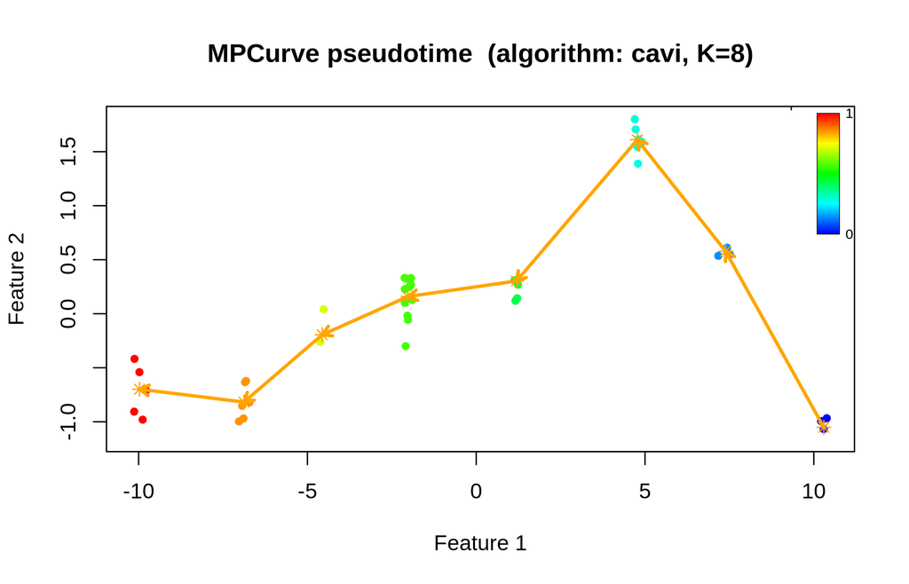

Figure 1. Observed Feature 1 and Feature 2 pairs, colored by inferred pseudotime, with the posterior-mean trajectory in orange. The 20 samples missing Feature 1 are omitted from this plot but remain in the fit through their other observed features.

```r
plot(fit, dims = c(1, 2))
```

Figure 2 shows the fitting objective and plug-in likelihood. This example uses the default intrinsic RW2 fitting prior and its fixed-convention variational objective.

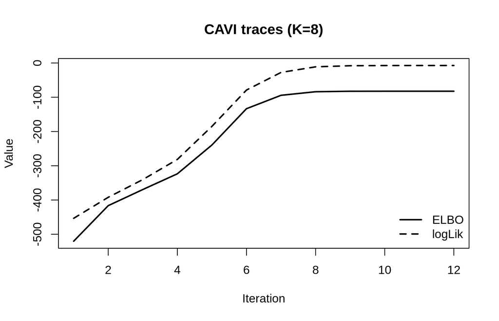

Figure 2. CAVI traces on the observed entries: solid, variational objective under the default intrinsic-prior convention; dashed, plug-in observed-data log likelihood evaluated at the posterior-mean trajectories.

```r
plot(fit, plot_type = "elbo")
```

**Reproduction details**

The simulation and fitting seeds are both 1, with an eight-bin RW2 generator, generator ridge 0.001, smoothness range 0.5–3, noise SD range 0.08–0.18, and uniform position probabilities. Fitting uses eight bins, PCA initialization, adaptive position probabilities, estimated feature noise, and at most 100 sweeps; other settings are the 0.4.2 defaults. The version was developed from commit `4f8b583d7549d4068d0e810e93f90653cbcb2ed9`; the adjacent `source-sha256.txt` identifies the tested source.